# Interactive Linear Regression Tutorial

Welcome! This notebook will help you understand linear regression through interactive visualizations and hands-on experimentation.

## What is Linear Regression?

Linear regression is a fundamental machine learning algorithm used to predict a continuous target variable based on one or more input features. The goal is to find the best-fitting straight line (or hyperplane in higher dimensions) through the data points.

### The Equation

For simple linear regression with one feature: $$y = mx + b$$

Where:

- $y$ is the predicted output (dependent variable)
- $x$ is the input feature (independent variable)
- $m$ is the slope of the line
- $b$ is the y-intercept

### Learning Objectives

By the end of this notebook, you will:

1. Understand the concept of linear regression
2. See how different parameters affect the regression line
3. Learn about cost functions (Mean Squared Error)
4. Experiment with different datasets
5. Understand the impact of outliers

```python
# Import necessary libraries
import numpy as np
import matplotlib.pyplot as plt
from ipywidgets import interact, interactive, fixed, interact_manual
import ipywidgets as widgets
from IPython.display import display
import warnings
warnings.filterwarnings('ignore')

# Set up matplotlib for better plots
try:
    plt.style.use('seaborn-v0_8-darkgrid')
except:
    try:
        plt.style.use('seaborn-darkgrid')
    except:
        plt.style.use('default')
%matplotlib inline

print("✅ All libraries imported successfully!")
print("📊 Ready to explore linear regression!")
```

```
✅ All libraries imported successfully!
📊 Ready to explore linear regression!
```

## Part 1: Understanding the Regression Line

**What you'll see:** Adjust the sliders to change the slope and intercept of the regression line. Watch how the **Mean Squared Error (MSE)** changes as you move the line closer or farther from the data points.

**Key insight:** The goal is to find the line that minimizes MSE - notice how the error decreases when the line passes through the center of the data cloud.

```python
# Generate data once (outside the function) so it doesn't change when sliders move
np.random.seed(42)  # Fixed seed for reproducible data
x_data_fixed = np.linspace(0, 10, 20)
y_data_fixed = 2 * x_data_fixed + 3 + np.random.normal(0, 2, 20)  # True relationship with noise

def plot_regression_line(slope, intercept, show_points=True):
    """
    Plot a regression line with adjustable slope and intercept
    """
    fig, ax = plt.subplots(figsize=(10, 6), facecolor='white')

    # Use the fixed data points (generated above)
    x_data = x_data_fixed
    y_data = y_data_fixed

    # Calculate the regression line
    x_line = np.linspace(0, 10, 100)
    y_line = slope * x_line + intercept

    # Plot data points
    if show_points:
        ax.scatter(x_data, y_data, alpha=0.7, s=120, color='#2E86AB',
                  edgecolors='white', linewidth=1.5, label='Data', zorder=3)

    # Plot regression line
    ax.plot(x_line, y_line, '#E63946', linewidth=3.5,
           label=f'y = {slope:.2f}x + {intercept:.2f}', zorder=2)

    # Calculate and display MSE
    if show_points:
        y_pred = slope * x_data + intercept
        mse = np.mean((y_data - y_pred) ** 2)
        ax.text(0.02, 0.98, f'MSE: {mse:.2f}',
                transform=ax.transAxes, fontsize=13, fontweight='bold',
                verticalalignment='top',
                bbox=dict(boxstyle='round,pad=0.5', facecolor='#F1FAEE',
                         edgecolor='#457B9D', linewidth=2, alpha=0.9))

    ax.set_xlabel('X', fontsize=13, fontweight='medium')
    ax.set_ylabel('Y', fontsize=13, fontweight='medium')
    ax.set_title('Interactive Regression Line', fontsize=15, fontweight='bold', pad=15)
    ax.legend(loc='upper left', fontsize=11, framealpha=0.9)
    ax.grid(True, alpha=0.2, linestyle='--')
    ax.set_xlim(0, 10)
    ax.set_ylim(0, 25)
    ax.spines['top'].set_visible(False)
    ax.spines['right'].set_visible(False)
    plt.tight_layout()
    plt.show()

# Create interactive widget
interact(plot_regression_line,
         slope=widgets.FloatSlider(value=2.0, min=-5.0, max=5.0, step=0.1, description='Slope (m)'),
         intercept=widgets.FloatSlider(value=3.0, min=-5.0, max=10.0, step=0.1, description='Intercept (b)'),
         show_points=widgets.Checkbox(value=True, description='Show Data Points'))
```

```
<function __main__.plot_regression_line(slope, intercept, show_points=True)>
```

## Part 2: Finding the Best Fit Line

### Understanding the Cost Landscape

**Left plot:** Shows your regression line with error bars (green dashed lines) connecting each data point to the line. The length of these bars represents the prediction error.

**Right plot (Cost Landscape):** This is a 2D map showing how MSE changes for different combinations of slope and intercept:

- **Contour lines** (like elevation on a map) show regions with similar MSE values
- **Darker colors** = Lower MSE (better fit)
- **Lighter colors** = Higher MSE (worse fit)
- **Red star** = Your current position
- **Green dot** = Optimal solution (lowest MSE)

**Try this:** Move the sliders and watch the red star move across the landscape. Notice how the MSE changes as you approach the green dot (optimal solution)!

### The Cost Function: Mean Squared Error (MSE)

$$MSE = \frac{1}{n}\sum_{i=1}^{n}(y_i - \hat{y}_i)^2$$

Our goal: Find the slope and intercept that minimize MSE.

```python
def plot_with_cost_landscape(slope, intercept, show_landscape=True):
    """
    Visualize the regression line and the cost landscape
    """
    # Generate sample data
    np.random.seed(42)
    x_data = np.linspace(0, 10, 15)
    true_slope, true_intercept = 2.5, 3.0
    y_data = true_slope * x_data + true_intercept + np.random.normal(0, 1.5, 15)

    if show_landscape:
        fig, (ax1, ax2) = plt.subplots(1, 2, figsize=(16, 6), facecolor='white')
    else:
        fig, ax1 = plt.subplots(1, 1, figsize=(10, 6), facecolor='white')

    # Plot 1: Regression line
    x_line = np.linspace(0, 10, 100)
    y_line = slope * x_line + intercept

    ax1.scatter(x_data, y_data, alpha=0.7, s=120, color='#2E86AB',
               edgecolors='white', linewidth=1.5, label='Data', zorder=3)
    ax1.plot(x_line, y_line, '#E63946', linewidth=3.5,
            label=f'y = {slope:.2f}x + {intercept:.2f}', zorder=2)

    # Draw error lines
    y_pred = slope * x_data + intercept
    for i in range(len(x_data)):
        ax1.plot([x_data[i], x_data[i]], [y_data[i], y_pred[i]],
                '#06A77D', linestyle='--', alpha=0.4, linewidth=1.5, zorder=1)

    # Calculate MSE
    mse = np.mean((y_data - y_pred) ** 2)

    ax1.set_xlabel('X', fontsize=13, fontweight='medium')
    ax1.set_ylabel('Y', fontsize=13, fontweight='medium')
    ax1.set_title(f'Regression Line  |  MSE: {mse:.2f}', fontsize=14, fontweight='bold', pad=15)
    ax1.legend(loc='upper left', fontsize=11, framealpha=0.9)
    ax1.grid(True, alpha=0.2, linestyle='--')
    ax1.set_xlim(0, 10)
    ax1.set_ylim(0, 30)
    ax1.spines['top'].set_visible(False)
    ax1.spines['right'].set_visible(False)

    # Plot 2: Cost landscape
    if show_landscape:
        # Create a grid of slope and intercept values
        slope_range = np.linspace(0, 5, 60)
        intercept_range = np.linspace(0, 6, 60)
        S, I = np.meshgrid(slope_range, intercept_range)

        # Calculate MSE for each combination
        MSE_grid = np.zeros_like(S)
        for i in range(len(slope_range)):
            for j in range(len(intercept_range)):
                y_pred_grid = S[j, i] * x_data + I[j, i]
                MSE_grid[j, i] = np.mean((y_data - y_pred_grid) ** 2)

        # Plot filled contour
        contour_filled = ax2.contourf(S, I, MSE_grid, levels=25, cmap='viridis', alpha=0.6)
        contour_lines = ax2.contour(S, I, MSE_grid, levels=15, colors='white', alpha=0.3, linewidths=0.8)

        # Mark current position
        ax2.plot(slope, intercept, '*', color='#E63946', markersize=25,
                markeredgecolor='white', markeredgewidth=2, label='Current', zorder=6)

        # Mark optimal position (calculated)
        optimal_slope = np.sum((x_data - np.mean(x_data)) * (y_data - np.mean(y_data))) / np.sum((x_data - np.mean(x_data))**2)
        optimal_intercept = np.mean(y_data) - optimal_slope * np.mean(x_data)
        ax2.plot(optimal_slope, optimal_intercept, 'o', color='#06A77D', markersize=18,
                markeredgecolor='white', markeredgewidth=2, label='Optimal', zorder=6)

        # Add colorbar
        cbar = plt.colorbar(contour_filled, ax=ax2, pad=0.02)
        cbar.set_label('MSE', fontsize=11, fontweight='medium')

        ax2.set_xlabel('Slope (m)', fontsize=13, fontweight='medium')
        ax2.set_ylabel('Intercept (b)', fontsize=13, fontweight='medium')
        ax2.set_title('Cost Landscape', fontsize=14, fontweight='bold', pad=15)
        ax2.legend(loc='upper right', fontsize=11, framealpha=0.9)
        ax2.grid(True, alpha=0.2, linestyle='--')
        ax2.spines['top'].set_visible(False)
        ax2.spines['right'].set_visible(False)

    plt.tight_layout()
    plt.show()

    # Print optimal values
    if show_landscape:
        optimal_slope = np.sum((x_data - np.mean(x_data)) * (y_data - np.mean(y_data))) / np.sum((x_data - np.mean(x_data))**2)
        optimal_intercept = np.mean(y_data) - optimal_slope * np.mean(x_data)
        optimal_mse = np.mean((y_data - (optimal_slope * x_data + optimal_intercept)) ** 2)
        print(f"🎯 Optimal: m={optimal_slope:.3f}, b={optimal_intercept:.3f}, MSE={optimal_mse:.3f}")
        print(f"📍 Current: m={slope:.2f}, b={intercept:.2f}, MSE={mse:.3f}")

interact(plot_with_cost_landscape,
         slope=widgets.FloatSlider(value=2.0, min=0.0, max=5.0, step=0.1, description='Slope (m)'),
         intercept=widgets.FloatSlider(value=3.0, min=0.0, max=6.0, step=0.1, description='Intercept (b)'),
         show_landscape=widgets.Checkbox(value=True, description='Show Cost Landscape'))
```

```
<function __main__.plot_with_cost_landscape(slope, intercept, show_landscape=True)>
```

## Part 3: Impact of Noise and Outliers

**What you'll see:**

- **Green dashed line** = True underlying relationship (what we're trying to find)
- **Red solid line** = Fitted regression line (what the model learned)
- **Red circles** = Outliers (if any)

**Experiment:** Increase noise and add outliers to see how they pull the regression line away from the true relationship. Notice how outliers can dramatically affect the slope and intercept!

```python
def plot_noise_impact(noise_level, num_outliers, outlier_magnitude):
    """
    Visualize how noise and outliers affect linear regression
    """
    fig, ax = plt.subplots(figsize=(12, 7), facecolor='white')

    # True relationship
    true_slope, true_intercept = 2.0, 3.0
    x_data = np.linspace(0, 10, 30)
    y_true = true_slope * x_data + true_intercept

    # Add noise
    np.random.seed(42)
    noise = np.random.normal(0, noise_level, len(x_data))
    y_data = y_true + noise

    # Add outliers
    outlier_indices = []
    if num_outliers > 0:
        outlier_indices = np.random.choice(len(x_data), num_outliers, replace=False)
        y_data[outlier_indices] += np.random.choice([-1, 1], num_outliers) * outlier_magnitude

    # Calculate regression line from noisy data
    slope = np.sum((x_data - np.mean(x_data)) * (y_data - np.mean(y_data))) / np.sum((x_data - np.mean(x_data))**2)
    intercept = np.mean(y_data) - slope * np.mean(x_data)

    # Plot true line
    x_line = np.linspace(0, 10, 100)
    y_true_line = true_slope * x_line + true_intercept
    y_pred_line = slope * x_line + intercept

    # Plot regular data points
    regular_mask = np.ones(len(x_data), dtype=bool)
    if len(outlier_indices) > 0:
        regular_mask[outlier_indices] = False

    ax.scatter(x_data[regular_mask], y_data[regular_mask], alpha=0.6, s=100,
              color='#2E86AB', edgecolors='white', linewidth=1, label='Data', zorder=3)

    # Highlight outliers
    if len(outlier_indices) > 0:
        ax.scatter(x_data[outlier_indices], y_data[outlier_indices],
                  s=200, facecolors='none', edgecolors='#E63946', linewidth=3,
                  label='Outliers', zorder=5)

    ax.plot(x_line, y_true_line, '#06A77D', linestyle='--', linewidth=3,
           label=f'True: y = {true_slope}x + {true_intercept}', alpha=0.8, zorder=2)
    ax.plot(x_line, y_pred_line, '#E63946', linewidth=3.5,
           label=f'Fitted: y = {slope:.2f}x + {intercept:.2f}', zorder=2)

    # Calculate metrics
    mse = np.mean((y_data - (slope * x_data + intercept)) ** 2)
    r_squared = 1 - np.sum((y_data - (slope * x_data + intercept))**2) / np.sum((y_data - np.mean(y_data))**2)

    ax.set_xlabel('X', fontsize=13, fontweight='medium')
    ax.set_ylabel('Y', fontsize=13, fontweight='medium')
    ax.set_title('Noise & Outliers Impact', fontsize=15, fontweight='bold', pad=15)
    ax.legend(loc='upper left', fontsize=11, framealpha=0.9)
    ax.grid(True, alpha=0.2, linestyle='--')
    ax.set_xlim(-0.5, 10.5)
    ax.spines['top'].set_visible(False)
    ax.spines['right'].set_visible(False)

    # Add metrics box
    textstr = f'MSE: {mse:.1f}\nR²: {r_squared:.3f}'
    ax.text(0.98, 0.02, textstr, transform=ax.transAxes, fontsize=12, fontweight='bold',
            verticalalignment='bottom', horizontalalignment='right',
            bbox=dict(boxstyle='round,pad=0.6', facecolor='#F1FAEE',
                     edgecolor='#457B9D', linewidth=2, alpha=0.9))

    plt.tight_layout()
    plt.show()

interact(plot_noise_impact,
         noise_level=widgets.FloatSlider(value=1.0, min=0.0, max=5.0, step=0.1, description='Noise Level'),
         num_outliers=widgets.IntSlider(value=0, min=0, max=5, step=1, description='Number of Outliers'),
         outlier_magnitude=widgets.FloatSlider(value=5.0, min=0.0, max=15.0, step=0.5, description='Outlier Size'))
```

```
<function __main__.plot_noise_impact(noise_level, num_outliers, outlier_magnitude)>
```

## Part 4: Gradient Descent Visualization

**What you'll see:**

- **Left plot:** Final regression line after training (green dashed = true line, red = learned line)
- **Middle plot:** How slope and intercept converge to optimal values over iterations
- **Right plot:** How MSE decreases over time (plotted on log scale)

```python
def gradient_descent_visualization(learning_rate, num_iterations, show_animation=True):
    """
    Visualize gradient descent optimization
    """
    # Generate sample data
    np.random.seed(42)
    x_data = np.linspace(0, 10, 20)
    true_slope, true_intercept = 2.5, 3.0
    y_data = true_slope * x_data + true_intercept + np.random.normal(0, 1.5, 20)

    # Initialize parameters
    slope = 0.5
    intercept = 1.0

    # Store history for visualization
    slope_history = [slope]
    intercept_history = [intercept]
    mse_history = []

    # Gradient descent
    n = len(x_data)
    for i in range(num_iterations):
        # Predictions
        y_pred = slope * x_data + intercept

        # Calculate gradients
        slope_gradient = -(2/n) * np.sum(x_data * (y_data - y_pred))
        intercept_gradient = -(2/n) * np.sum(y_data - y_pred)

        # Update parameters
        slope = slope - learning_rate * slope_gradient
        intercept = intercept - learning_rate * intercept_gradient

        # Store history
        slope_history.append(slope)
        intercept_history.append(intercept)
        mse = np.mean((y_data - y_pred) ** 2)
        mse_history.append(mse)

    # Create figure with subplots
    fig = plt.figure(figsize=(16, 6), facecolor='white')
    gs = fig.add_gridspec(1, 3, hspace=0.3, wspace=0.35)
    ax1 = fig.add_subplot(gs[0, 0])
    ax2 = fig.add_subplot(gs[0, 1])
    ax3 = fig.add_subplot(gs[0, 2])

    # Plot 1: Final regression line
    x_line = np.linspace(0, 10, 100)
    y_line = slope * x_line + intercept
    y_true_line = true_slope * x_line + true_intercept

    ax1.scatter(x_data, y_data, alpha=0.6, s=100, color='#2E86AB',
               edgecolors='white', linewidth=1, label='Data', zorder=3)
    ax1.plot(x_line, y_true_line, '#06A77D', linestyle='--', linewidth=3,
            label='True', alpha=0.8, zorder=2)
    ax1.plot(x_line, y_line, '#E63946', linewidth=3.5,
            label=f'Learned: {slope:.2f}x + {intercept:.2f}', zorder=2)
    ax1.set_xlabel('X', fontsize=12, fontweight='medium')
    ax1.set_ylabel('Y', fontsize=12, fontweight='medium')
    ax1.set_title('Final Model', fontsize=13, fontweight='bold', pad=12)
    ax1.legend(loc='upper left', fontsize=10, framealpha=0.9)
    ax1.grid(True, alpha=0.2, linestyle='--')
    ax1.spines['top'].set_visible(False)
    ax1.spines['right'].set_visible(False)

    # Plot 2: Parameter convergence
    iterations = range(len(slope_history))
    ax2.plot(iterations, slope_history, color='#2E86AB', linewidth=2.5,
            label='Slope', marker='o', markersize=5, markevery=max(1, len(iterations)//10))
    ax2.axhline(y=true_slope, color='#2E86AB', linestyle='--', alpha=0.5, linewidth=2)
    ax2_twin = ax2.twinx()
    ax2_twin.plot(iterations, intercept_history, color='#E63946', linewidth=2.5,
                 label='Intercept', marker='s', markersize=5, markevery=max(1, len(iterations)//10))
    ax2_twin.axhline(y=true_intercept, color='#E63946', linestyle='--', alpha=0.5, linewidth=2)
    ax2.set_xlabel('Iteration', fontsize=12, fontweight='medium')
    ax2.set_ylabel('Slope', fontsize=12, fontweight='medium', color='#2E86AB')
    ax2_twin.set_ylabel('Intercept', fontsize=12, fontweight='medium', color='#E63946')
    ax2.set_title('Parameter Convergence', fontsize=13, fontweight='bold', pad=12)
    ax2.grid(True, alpha=0.2, linestyle='--')
    ax2.legend(loc='upper left', fontsize=10, framealpha=0.9)
    ax2_twin.legend(loc='upper right', fontsize=10, framealpha=0.9)
    ax2.spines['top'].set_visible(False)
    ax2_twin.spines['top'].set_visible(False)

    # Plot 3: MSE convergence
    ax3.plot(range(1, len(mse_history)+1), mse_history, color='#06A77D',
            linewidth=2.5, marker='o', markersize=5, markevery=max(1, len(mse_history)//10))
    ax3.set_xlabel('Iteration', fontsize=12, fontweight='medium')
    ax3.set_ylabel('MSE (log scale)', fontsize=12, fontweight='medium')
    ax3.set_title('Cost Convergence', fontsize=13, fontweight='bold', pad=12)
    ax3.grid(True, alpha=0.2, linestyle='--')
    ax3.set_yscale('log')
    ax3.spines['top'].set_visible(False)
    ax3.spines['right'].set_visible(False)

    plt.tight_layout()
    plt.show()

    print(f"✅ Final: m={slope:.3f} (true: {true_slope:.3f}), b={intercept:.3f} (true: {true_intercept:.3f}), MSE={mse_history[-1]:.3f}")

interact(gradient_descent_visualization,
         learning_rate=widgets.FloatSlider(value=0.01, min=0.001, max=0.1, step=0.001, description='Learning Rate'),
         num_iterations=widgets.IntSlider(value=50, min=10, max=200, step=10, description='Iterations'),
         show_animation=widgets.Checkbox(value=True, description='Show Animation'))
```

```
<function __main__.gradient_descent_visualization(learning_rate, num_iterations, show_animation=True)>
```

## Part 5: Real-World Example - Steel Hardness Prediction

**What you'll see:** A materials engineering application where we predict steel hardness (HRC) based on carbon content. The red star shows your prediction for the selected carbon percentage. Adjust the slider to see how hardness changes with carbon content!

**Materials Engineering Context:** In steel, increasing carbon content generally increases hardness due to the formation of harder microstructures. This linear relationship is fundamental in materials design and heat treatment processes.

```python
def steel_hardness_prediction(carbon_content, show_all_data=True):
    """
    Predict steel hardness (HRC) based on carbon content using linear regression
    """
    # Simulate realistic steel hardness data
    # Typical relationship: Hardness increases with carbon content
    np.random.seed(42)
    carbon_levels = np.array([0.1, 0.15, 0.2, 0.25, 0.3, 0.35, 0.4, 0.45, 0.5, 0.55,
                              0.6, 0.65, 0.7, 0.75, 0.8, 0.85, 0.9, 0.95])  # Carbon % (wt%)

    # Hardness = base hardness + (hardness per % carbon) * carbon + noise
    # Typical: ~20 HRC base, ~50 HRC per % carbon (for quenched steel)
    base_hardness = 20  # HRC
    hardness_per_carbon = 50  # HRC per % carbon
    hardness = base_hardness + hardness_per_carbon * carbon_levels + np.random.normal(0, 3, len(carbon_levels))
    hardness = np.maximum(hardness, 15)  # Minimum hardness
    hardness = np.minimum(hardness, 70)  # Maximum practical hardness

    # Fit linear regression
    slope = np.sum((carbon_levels - np.mean(carbon_levels)) * (hardness - np.mean(hardness))) / np.sum((carbon_levels - np.mean(carbon_levels))**2)
    intercept = np.mean(hardness) - slope * np.mean(carbon_levels)

    # Predict for given carbon content
    predicted_hardness = slope * carbon_content + intercept
    predicted_hardness = max(15, min(70, predicted_hardness))  # Clamp to reasonable range

    # Create visualization
    fig, ax = plt.subplots(figsize=(12, 7), facecolor='white')

    if show_all_data:
        ax.scatter(carbon_levels * 100, hardness, alpha=0.6, s=120, color='#2E86AB',
                  edgecolors='white', linewidth=1.5, label='Experimental Data', zorder=3)

    # Plot regression line
    x_line = np.linspace(0, 1.0, 100)
    y_line = slope * x_line + intercept
    y_line = np.maximum(y_line, 15)  # Clamp to reasonable range
    y_line = np.minimum(y_line, 70)
    ax.plot(x_line * 100, y_line, '#E63946', linewidth=3.5,
           label=f'Model: {slope:.1f} HRC/%C + {intercept:.1f} HRC', zorder=2)

    # Highlight prediction
    ax.scatter([carbon_content * 100], [predicted_hardness], s=400, color='#E63946',
              marker='*', edgecolors='white', linewidth=2.5,
              label=f'Prediction: {predicted_hardness:.1f} HRC', zorder=5)
    ax.axvline(x=carbon_content * 100, color='#E63946', linestyle='--', alpha=0.4, linewidth=2)
    ax.axhline(y=predicted_hardness, color='#E63946', linestyle='--', alpha=0.4, linewidth=2)

    ax.set_xlabel('Carbon Content (% wt)', fontsize=13, fontweight='medium')
    ax.set_ylabel('Hardness (HRC)', fontsize=13, fontweight='medium')
    ax.set_title('Steel Hardness Prediction', fontsize=15, fontweight='bold', pad=15)
    ax.legend(loc='lower right', fontsize=11, framealpha=0.9)
    ax.grid(True, alpha=0.2, linestyle='--')
    ax.set_xlim(0, 100)
    ax.set_ylim(10, 75)
    ax.spines['top'].set_visible(False)
    ax.spines['right'].set_visible(False)

    plt.tight_layout()
    plt.show()

    print(f"🔩 {carbon_content:.2f}% C → {predicted_hardness:.1f} HRC (Hardness increase: {slope:.1f} HRC per %C)")

interact(steel_hardness_prediction,
         carbon_content=widgets.FloatSlider(value=0.5, min=0.1, max=1.0, step=0.01, description='Carbon Content (%)'),
         show_all_data=widgets.Checkbox(value=True, description='Show All Data'))
```

```
<function __main__.steel_hardness_prediction(carbon_content, show_all_data=True)>
```

## Part 6: Try It Yourself!

Now it's your turn! Experiment with the code below to create your own linear regression model.

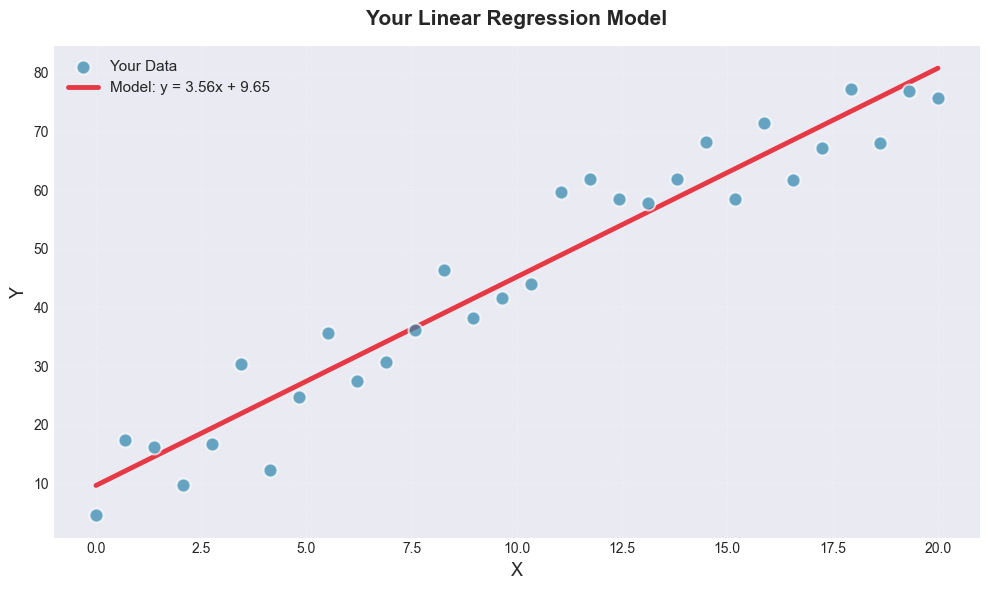

```
📊 Your Model Performance:
   Slope: 3.557 (True: 3.500)
   Intercept: 9.650 (True: 10.000)
   Mean Squared Error: 33.94
   R² Score: 0.930

💡 Try modifying the code above to:
   - Change the true relationship (slope and intercept)
   - Adjust the amount of noise
   - Add outliers and see their impact
   - Use your own real data!
```

```python
# YOUR TURN: Create your own dataset and fit a linear regression model!

# Step 1: Generate or load your data
# Example: Create data with a known relationship
np.random.seed(123)
x_custom = np.linspace(0, 20, 30)
true_slope_custom = 3.5
true_intercept_custom = 10.0
y_custom = true_slope_custom * x_custom + true_intercept_custom + np.random.normal(0, 5, 30)

# Step 2: Calculate the regression coefficients manually
# Slope (m) = Σ(x - x̄)(y - ȳ) / Σ(x - x̄)²
x_mean = np.mean(x_custom)
y_mean = np.mean(y_custom)
slope_custom = np.sum((x_custom - x_mean) * (y_custom - y_mean)) / np.sum((x_custom - x_mean)**2)

# Intercept (b) = ȳ - m × x̄
intercept_custom = y_mean - slope_custom * x_mean

# Step 3: Make predictions
x_pred = np.linspace(0, 20, 100)
y_pred = slope_custom * x_pred + intercept_custom

# Step 4: Visualize
fig, ax = plt.subplots(figsize=(10, 6), facecolor='white')
ax.scatter(x_custom, y_custom, alpha=0.7, s=100, color='#2E86AB',
          edgecolors='white', linewidth=1.5, label='Your Data', zorder=3)
ax.plot(x_pred, y_pred, '#E63946', linewidth=3.5,
        label=f'Model: y = {slope_custom:.2f}x + {intercept_custom:.2f}', zorder=2)
ax.set_xlabel('X', fontsize=13, fontweight='medium')
ax.set_ylabel('Y', fontsize=13, fontweight='medium')
ax.set_title('Your Linear Regression Model', fontsize=15, fontweight='bold', pad=15)
ax.legend(loc='best', fontsize=11, framealpha=0.9)
ax.grid(True, alpha=0.2, linestyle='--')
ax.spines['top'].set_visible(False)
ax.spines['right'].set_visible(False)
plt.tight_layout()
plt.show()

# Step 5: Evaluate your model
mse_custom = np.mean((y_custom - (slope_custom * x_custom + intercept_custom))**2)
r2_custom = 1 - np.sum((y_custom - (slope_custom * x_custom + intercept_custom))**2) / np.sum((y_custom - y_mean)**2)

print(f"📊 Your Model Performance:")
print(f"   Slope: {slope_custom:.3f} (True: {true_slope_custom:.3f})")
print(f"   Intercept: {intercept_custom:.3f} (True: {true_intercept_custom:.3f})")
print(f"   Mean Squared Error: {mse_custom:.2f}")
print(f"   R² Score: {r2_custom:.3f}")

print("\n💡 Try modifying the code above to:")
print("   - Change the true relationship (slope and intercept)")
print("   - Adjust the amount of noise")
print("   - Add outliers and see their impact")
print("   - Use your own real data!")
```

## Summary and Key Takeaways

### What We Learned:

1. **Linear Regression Basics**: A simple yet powerful method to model relationships between variables
   - Equation: $y = mx + b$
   - Goal: Find the best line that minimizes prediction error
2. **Cost Function**: Mean Squared Error (MSE) measures how well our model fits the data
   - Lower MSE = Better fit
   - We want to minimize MSE
3. **Optimization**: Gradient descent helps us find optimal parameters
   - Iteratively updates parameters
   - Learning rate controls step size
4. **Real-World Considerations**:
   - Noise affects model accuracy
   - Outliers can significantly impact results
   - More data generally leads to better models

### Next Steps:

- Explore **multiple linear regression** (multiple features)
- Learn about **regularization** (Ridge, Lasso)
- Study **polynomial regression** for non-linear relationships
- Understand **evaluation metrics** (R², MAE, RMSE)

### Practice Questions:

1. What happens to the regression line if you increase the noise level?
2. How do outliers affect the slope and intercept?
3. What is the relationship between learning rate and convergence speed?
4. Can you think of other materials engineering applications of linear regression? (e.g., temperature vs. thermal expansion, composition vs. electrical conductivity, processing time vs. grain size)

**Happy Learning! 🎓📊**